# 10_1_Numpy-Clase slides

### 8.6 EJERCICIOS

### Ejercicio 1

Dado el array:

data2 = np.array([

```
            [5, 2, 3, 6],
            [4, 5, 6, 4],
            [3, 6, 5, 3],
            [6, 5, 6, 5]
            ])
```

1. Averigua cual es su estructura, dimensión, tamaño y tipo de datos de sus elementos. Representalo todo de forma clara identificando cada característica.
2. Muesta el pantalla el elemento mayor y menor del array así como su posición.
3. Muestra los mayores y menores por filas y columnas.
4. Averigua como mostrar la posición de los mayores y menores de cada fila y columna.

### 9. Indexacion y Seleccion de rangos (Slicing) en NumPy

Como indexar y seleccionar elementos o grupos de elementos de un array

```python
#Creando un arreglo de ejemplo
arr = np.arange(0,11) # Generar un arreglo de enteros del 0 hasta el 10
```

```python
arr.dtype # tipos de datos dentro del arreglo
```

### 9.1 Indexación y Slicing de Arrays 1D

Podemos indexar y dividir Arrays NumPy de la misma manera que puede dividir listas de Python.

```python
data = np.arange(20)
print(data)
```

```python
# Obtener un valor conociendo su indice (index)
data[8]
```

```python
#Obtener los valores en un rango [valor_inicial, valor_final -1]
data[1:5]
```

```python
#Obtener los valores en un rango [valor_inicial, valor_final -1] por ejemplo desde 0-5
data[0:5]
```

```python
#desde el 1 hasta el final
```

```python
#desde el penultimo hasta el final. Como sería?
```

De inicio a 9 de tres en tres elementos

```python
data[:10:3] # De inicio a 9 de tres en tres elementos
```

De 6 a fin de dos en dos elementos

```python
data[6::2] # De 6 a fin de dos en dos elementos
```

De inicio hasta el elemento -3 del array

```python
data[:-3] # De inicio hasta el elemento -3 del array
```

Array reverso

```python
data[::-1]
```

De fin (reverso) a inicio tomados de 2 en 2

```python
#como sería?
```

### 9.1.1 EJERCICIOS

Del array data:

1. Quedate con los elementos comprendidos entre la posición 4 y 7.
2. Quedate con los elementos desde el antepenultimo hasta el final.
3. Quedate con los elementos desde el cuarto empezando por el final hasta el décimo empezando por atrás.
4. Quedate con los elementos de inicio a 15 de 5 en 5 elementos.
5. Quedate con los elementos de inicio hasta el elemento 7 empezando por el final del array.

#### soluciones:

### 9.2 Indexación y Slicing de Arrays 2D

El formato general es **arr_2d[fila][col]** o **arr_2d[fila,col].**

**Se recomienda usar la notacion con la coma por claridad.**

```python
# Creacion de una matriz de 3x3
arr_2d = np.array(([5,10,15],[20,25,30],[35,40,45]))

print(arr_2d)
```

```python
#Indexando por filas
arr_2d[1] # Obtener la fila 1 (recordar que el indice de python empieza en 0)
```

```python
# El formato es **arr_2d[fila][col]** o **arr_2d[fila,col]**

# Obteniendo un elemento en especifico
print(arr_2d[1][0]) # elemento de la fila 1 columna 0
print(arr_2d[1,0])
```

```python
# seleccion de rangos en Arrays 2D (slicing)

#dimensiones (2,2) desde la esquina superior derecha
arr_2d[:2,1:] # filas [0,1](el 2 no está incluido) y columnas 1 hasta el final.

#¿Qué valores mostrará?
```

```python
# fila de indice 2
arr_2d[2]
```

```python
# todos los elementos de las columnas que estan en la fila de posicion 2
arr_2d[2,:]
```

```python
a = np.array([
             [0,  1,  2,  3,  4,  5],
             [10, 11, 12, 13, 14, 15],
             [20, 21, 22, 23, 24, 25],
             [30, 31, 32, 33, 34, 35],
             [40, 41, 42, 43, 44, 45],
             [50, 51, 52, 53, 54, 55]])
print(a)
```

```python
#quiero la fila 1 y recorrer su elementos de 2 en dos
a[1:2, ::2] #--> filas 1 a 2(2 sin incluir). Columnas: desde inicio a fin, y el 2 indica que saltamos de dos en dos.
```

```python
#columna 1 de 3 en tres
a[::3, 1:2]
```

```python
#ahora quiero los elementos de las columnas 2 y 3 de dos en dos y en orden inverso.
a[::-2, 2:4]
```

### Ayudas para indexacion

La indexación de una matriz 2D puede ser un poco confusa al principio, especialmente cuando comienza a agregar pasos en la seleccion. La mejor forma de verlo es graficamente:

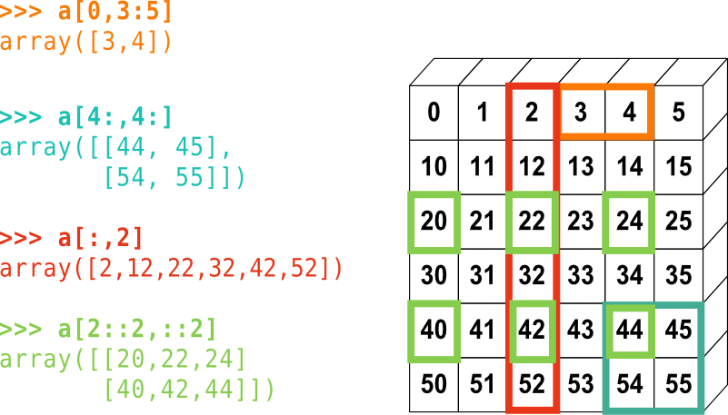

### 9.2.1 EJERCICIOS

Dado el array 2D `a` de los ejemplos anteriores.

1. Quédate con todos los elementos de la última columna(5-55)
2. Quédate con los elementos 0,1,10 y 11
3. Quédate con los elementos 22,23 y 24
4. Quédate con la diagonal de la matriz.
5. Pinta en pantalla todas las diagonales que estan por debajo y por encima de la diagonal principal.

   [10 21 32 43 54]

   [20 31 42 53]

   [30 41 52]

   [40 51]

   [50]

```
[5]

[ 4 15]

[ 3 14 25]

[ 2 13 24 35]

[ 1 12 23 34 45]
```

1. Quedate con los números pares de la fila 5.
2. Muesta la columna 1 en orden inverso y de 2 en 2 (50,30 y 10)
3. Todos los elementos de filas y columnas avanzando de 3 en 3:

   0,3,30,33

#### Solución:

### 9.2.1 Indexacion especial

La indexación especial permite **seleccionar filas o columnas enteras desordenadas.**

Vamos a montar un ejemplo para ver esta indexación de forma clara.

```python
#Creando una array de 10x10 de ceros
arr2d = np.zeros((10,10))
print(arr2d)

#Tamaño del array
arr_length = arr2d.shape[1]
print(f"Tamañao del array: {arr_length}")


# Creando una matriz con elementos que contienen el valor correspondiente a la posicion de la fila
for i in range(arr_length):
    arr2d[i] = i

print("\nMatriz del ejemplo:")
print(arr2d)
```

La indexacion especial permite:

```python
# sacar las filas 2, 4 , 6, 8
arr2d[[2,4,6,8]] # observe el uso de los dobles corchetes
```

```python
#Permite cualquier orden
arr2d[[6,4,2,7]]
```

Si qusieramos sacar columnas tendriamos que hacerlo así:

```python
a[[0,1,2,3,4,5],[0]]#columna 0 al completo. Pongo los indices de las filas que quiero y el indice de la columna
```

```python
a[[0,1],[0,1]]#dos primeros elementos de la diagonal principal
```

### EJERCICIO

Utilizando la indexación especial, realiza las siguientes operaciones:

1. Recupera todos los elementos de la fila 3
2. Recupera todos los elementos de la columna 5
3. Quedate con los elementos de las posiciones 1, 3 y 5 de la columna 3.
4. Muestra los elementos de las posiciones 1, 3 y 5 de la fila 6.
5. De la fila 3 saca el tercer elemento y de la fila 4 saca el quinto.

### 9.3 Seleccion de valores que cumplan ciertas condiciones

Si deseamos seleccionar valores de un array que cumplan con ciertas condiciones, es sencillo con NumPy.

**Basta con poner entre los [ ] la condición o condiciones que queramos utilizar.**

También acepta operadores lógicos aunque en numpy:

- and = &
- or = |

Por ejemplo, comencemos con la siguiente matriz:

```python
a = np.array([[1 , 2, 3, 4], [5, 6, 7, 8], [9, 10, 11, 12]])
print(a)
```

1) Selecciona todos los valores menores a 5

2) Selecciona todos los valores >=5 y menor o igual a 10

3) Selecciona todos los valores mayores que 11

```python
#1)
menores_5 = a[ a < 5]
print(menores_5)
```

```python
#podemos crear primero la condición y almacenarla en un array booleano

condi_menores_5 = (a < 5)
print(condi_menores_5)

#ahora usamos el array booleano para seleccionar los valores
menores_5 = a[condi_menores_5]
print(menores_5)
```

```python
#2 mayores o igual a 5 y menores o igual a 10
condi_2 = ((a >= 5) & (a <= 10))
print(condi_2)

seleccionados2 = a[condi_2]
print(seleccionados2)
```

```python
# 3) mayores a 11
condi_3 = (a > 11)
print(condi_3)
seleccionados3 = a[condi_3]
print(seleccionados3)
```

**Más ejemplos**

Supongamos que queremos eliminar todas las apariciones de 6 del siguiente array. Veamos cómo hacer eso.

```python
arr = np.array([4,5,6,7,8,9,10,11,4,5,6,33,6,7])
print(arr)
```

```python
# nos quedamos con todos los que sean distintos de 6 y así eliminamos los = 6
arr = arr[arr != 6]
print(arr)
```

### 9.4 Eliminar elementos por valor o condición usando np.argwhere () & np.delete ()

```python
#supongamos que tenemos el siguiente array
arr = np.array([4, 5, 6, 7, 8, 9, 10, 11, 4, 5, 6, 33, 6, 7])
```

Ahora eliminemos todas las apariciones de 6 del Array anterior usando np.argwhere () & np.delete ()

```python
arr = np.delete(arr, np.argwhere(arr == 6))#en este caso ponemos == queremos que borre los elementos que sean iguales a 6
print('Array modificado :')
print(arr)
```

Importante:

Lo que hace **np.argwhere es crear una Array de enteros** que luego utiliza delete para borrar solo aquellas posiciones.

```python
print(np.argwhere(arr == 7))
```

### 9.5 Broadcasting (Difusion)

Con las listas de python **no se pueden realizar operaciones elemento a elemento, pero con NumPy si se puede realizar.**

Vamos a ver como es el comportamiento de las listas ante las siguientes operaciones:

```python
# observar el comportamiento de las listas
lista = list(range(10))
print(lista)
```

```python
lista + lista # este procedimento lo que hace es concatenar las listas
```

```python
x = 2
lista*x # este procedimento hace que se repita la lista x numero de veces
```

Intentemos multiplicar cada elemento de la lista por 2

```python
mi_lista * 2
```

Nos duplica los elementos de la lista pero no mulplica por 2 cada elemento. Para hacerlo tendríamos que recorrer cada elemento y aplicarle la multiplicación. Pero qué ocurre con los arrays de Numpy?

```python
my_arr = np.array([1, 10, 20, 75])
```

```python
#probar a multiplicarlo
```

Los arrays están optimizados para realizar una misma operación sobre todos sus elementos.

### EJERCICIOS

```python
b = np.array([
             [0,  1,  2,  3,  4,  5],
             [10, 11, 12, 13, 14, 15],
             [20, 11, 22, 23, 24, 25],
             [30, 11, 32, 33, 34, 35],
             [40, 41, 42, 43, 44, 45],
             [50, 51, 52, 43, 54, 55]
            ])

print(b)
```

Dado el array b 2D. Realiza las operaciones que se indican a continuación.

**1. Quedate con los valores menores de 22.**

**2. De la columna 5, muestra únicamente los números que sean divisores de 7.**

**3. Quedate con los valores mayores a 22 y que sean menores de 33.**

**4. Elimina los valores 11 y 43. Almacena el resultado en un nuevo array.**

**5. Muestra los valores que sean multiplos de 9 ó de 7.**

**6. Del resultado obtenido en el punto 5, divide por 2 los 3 últimos valores.**

```python
#1)
```

```python
#2) Versión con mascara
```

```python
#2) version normal
```

```python
#3) mayores a 22 y menores a 33
```

```python
#4. Elimina los valores 11 y 43. Almacena el resultado en un nuevo array.
```

```python
#5. Muestra los valores que sean multiplos de 9 ó de 7.
```

```python
# 6. Del resultado obtenido en el punto 5, divide por 2 los 3 últimos valores.
```

### 10. Remodelando Arrays - Manipulando dimensiones

### 10.1 Reshape

Devuelve una vista de la matriz que contiene los mismos datos con una nueva distribucion. No modifica realmente la matriz.

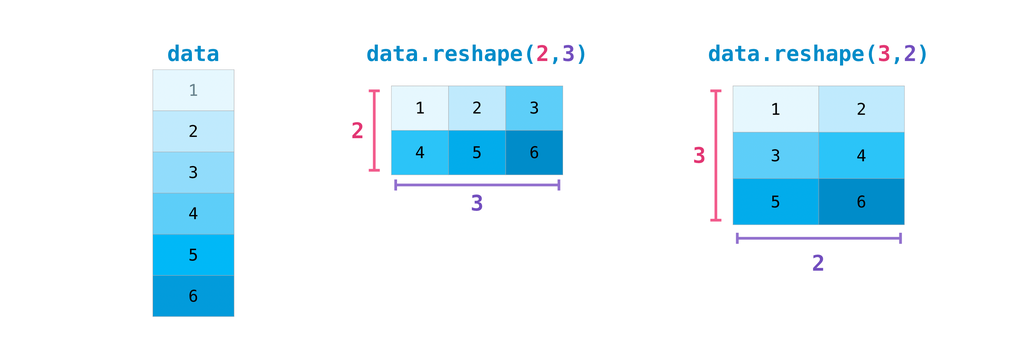

```python
data = np.arange(1,7)
print(data)
data.ndim

print(data.reshape(2,3))

print(data.reshape(3,2))
```

```python
# arr es un vector de 25 elementos y se convertira en una matriz de 5x5
arr = np.arange(25) #Genera un array de numeros enteros del 0 al 24
print(arr)
print(f"Array con {arr.size} elementos organizados: {arr.shape}. Ahora queremos reorganizar la matriz en 5x5")
arr.reshape(5,5)
```

```python
# Cambiando las dimensiones del arreglo para que sea una matriz
# de una sola dimension horizontal (1 fila y 25 columnas)
arr.reshape(1,25)
```

```python
# de una sola dimension vertical (1 columna y 25 filas)
arr.reshape(25,1)
```

```python
arr.reshape(25,1).shape
```

### Ejercicio 10.1.1

**Crea un vector de 48 elementos aleatorios entre el 1 y el 99(incluido) y organizalos en un array 3D.**

- Prueba a guardar el reshape en un nuevo array llamado arr2.
- En arr2 modifica el primer elemento y ponle el valor 99
- Muestra en pantalla arr1 y arr2. ¿Qué ha pasado?

Nota: como pongas los 48 elementos a mano, me jubilo.

```python
#qué pasa si modificamos arr2, por ejemplo el primer valor arr2[0][0][0] = 99


#QUÉ HA PASADO???
```

### 10.2 ravel y flatten

**Lo contrario de reshape, es la función `ravel y flatten`, es decir, eliminar todas las dimensiones y dejar un array plano.**

La principal diferencia entre los dos es que **flatten** devuelve una copia y **ravel** devuelve una vista, es decir, si hacemos un cambio en el array original, se verá reflejado en la variable asignada a ravel.

Es importante recordar que los arrays son mutables, es decir, si no realizamos una copia correctamente, los dos arrays compartirán las mismas posiciones de memoria.

```python
print(f"Antes de aplanar el array con ravel:\n{arr2}")
print(f"Aplanamos:\n{arr2.ravel()}")
print(f"Despues de aplanar el array con ravel:\n{arr2}")
```

```python
print("Aplanamos arr2 que tiene estructura 4x4x3")
print(f"Arr2:\n{arr2}")
arr3 = arr2.flatten()
print("Resultado de aplanar arr2:")
print(arr3)
```

```python
#Si modifico el primer elemento de arr3, cambiaré también arr1?
print("Ahora vamos a comprobar que arr3 es una copia independiente de arr2. Vamos a modificar el primer elemento de arr3 con un -1")
arr3[0]= -1

print(f"Arr2:\n{arr2}")
print(f"Arr3:\n{arr3}")
```

Como vemos, arr2 y arr3 son independientes, **porque flatten hace una copia completa.**

### Pregunta

¿Es posible reestructurar el siguiente array?

```python
preg_uno = np.random.randint(1,100,11)
preg_uno
```

### Pregunta

¿Es posible reestructurar el siguiente array en la estructura? `(4, 2)`

```python
preg_dos = np.array([
    [10, 30, 45, 150],
    [12, 40, 20, 10]
])
```

### Ejercicio 10.2.1

Escribe un Array 2D con los números del 100 al 112 (si es posible)

#### Solución

### 11. Convertir Arrays 1D en Arrays 2D (agregar un nuevo eje a un Array)

Para aumentar las dimensiones de nuestros Arrays, podemos usar:

- **np.newaxis**
- **np.expand_dims**

### np.newaxis

El uso **np.newaxis aumentará las dimensiones del Array en una dimensión cuando se use una vez.** Esto significa que un Array 1D se convertirá en un Array 2D , un Array 2D se convertirá en un Array 3D , y así sucesivamente.

Hagamos algunos ejemplos:

```python
a = np.array([1, 2, 3, 4, 5, 6])
a.shape
print(a)
```

```python
#Podemos usar np.newaxis para agregar un nuevo eje:

a2 = a[np.newaxis, :]#dentro del corchete creo el nuevo eje y separado por coma el vertor de inicio a fin(por eso los :)
print(a2.shape)
print(a2)
```

Por ejemplo, podemos convertir un Array 1D en un vector de fila insertando un eje a lo largo de la primera dimensión:

```python
row_vector = a[np.newaxis, :]
print(row_vector.shape)
print(row_vector)
```

O, para un vector de columna, poedemos insertar un eje a lo largo de la segunda dimensión:

```python
col_vector = a[:, np.newaxis]
print(col_vector.shape)
print(col_vector)
```

### np.expand_dims

También podemos expandir un array insertando un nuevo eje en una posición específica.

```python
#Por ejemplo, si empezamos con este array:

a = np.array([1, 2, 3, 4, 5, 6])
print(a.shape)
```

```python
#para agregar un eje en la posición de índice 1 con:

b = np.expand_dims(a, axis=1)
print(b.shape)
print(b)
```

```python
#Podemos agregar un eje en la posición de índice 0 con:

c = np.expand_dims(a, axis=0)
print(c.shape)
print(c)
```